# Using R with biological datasets 2026

### Exercise - relationship between two categorical variables

#### Introduction

We will be using the `lung` dataset from the `survival` package, focusing on two colums:

- `status`: censoring status 1=censored, 2=dead
- `sex`: Male=1 Female=2

(See below for futher details on the data set)

#### Setup script

```r
library(survival)
lung_new <- lung
lung_new$status <- factor(lung_new$status)
```

#### Tasks

1. Create a contingency table for sex versus status.
2. Perform a Chi-square test to see if the variables are independent.
3. Create a relevant plot.

#### Answers

```r
library(survival)
lung_new <- lung
lung_new$status <- factor(lung_new$status)

#1
lung_new |> tabyl(sex,status, show_na = FALSE)
```

```
 sex  1   2
   1 26 112
   2 37  53
```

```r
#2
lung_new |> tabyl(sex,status, show_na = FALSE) |> chisq.test()
```

```
    Pearson's Chi-squared test with Yates' continuity correction

data:  tabyl(lung_new, sex, status, show_na = FALSE)
X-squared = 12.42, df = 1, p-value = 0.0004247
```

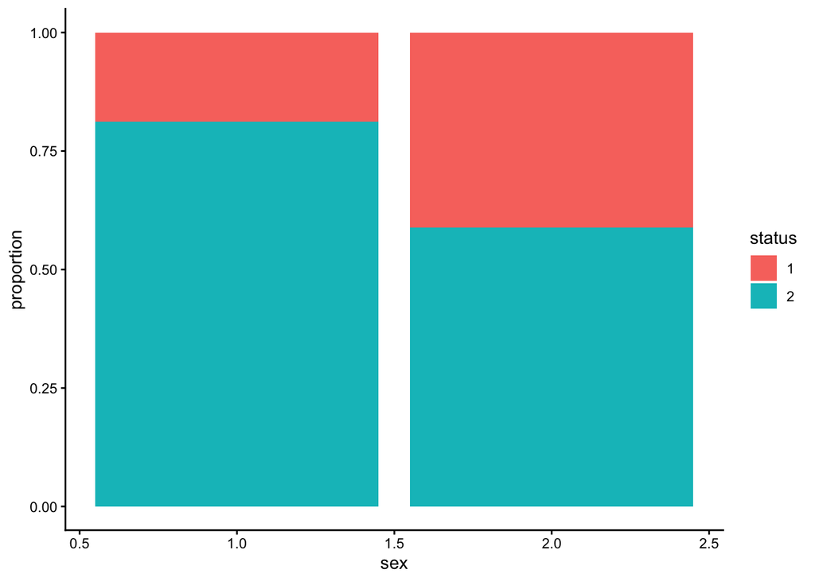

```r
#3
ggplot(lung_new, aes(x = sex, fill = status)) + geom_bar(position = "fill") + ylab("proportion")
```

# Time to event or survival analyses

In this part we will look at some of the steps you need to go through to create a test using biomarkers to predict a clinical outcome using real data from our recent prostate cancer bacterial biomarker paper.

[Video introducing survival analyses](https://www.youtube.com/watch?v=q0rzMgpYpbQ)

## Kaplan-Meier plots

To create the Kaplan-Meier plot we will be using the `ggsurvfit` R package. Please read about it’s use [here](https://www.danieldsjoberg.com/ggsurvfit/).

[Video introducing KM Plot and log-rank test](https://www.youtube.com/watch?v=t6vdjwhauF8&t=201s)

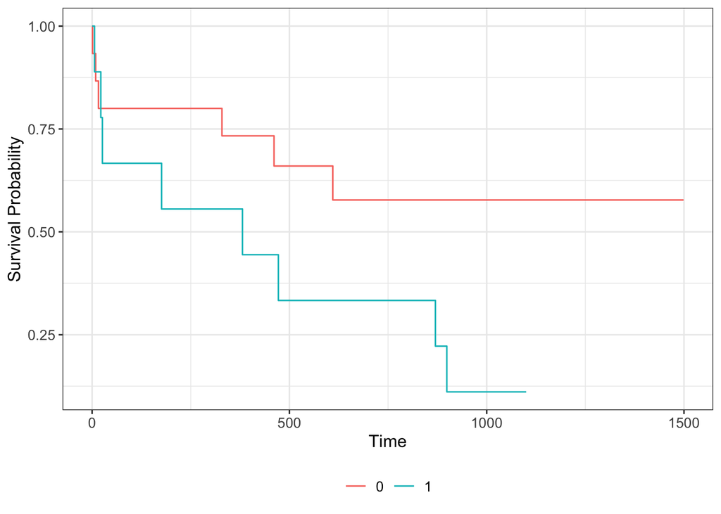

```r
library(survival)
library(ggsurvfit)
s16_merge <- read_rds("data/s16_merge.rds")
survfit2(Surv(progression_days, progression)~Peptoniphilus, data=s16_merge) |>
ggsurvfit()
```

### Exercise - Kaplan-Meier plots

#### Introduction

We’re going to be using the built-in `lung` cancer dataset that ships with the `survival` package. Columns:

1. `inst`: Institution code
2. **`time`: Survival time in days**
3. **`status`: censoring status 1=censored, 2=dead**
4. `age`: Age in years
5. **`sex`: Male=1 Female=2**
6. `ph.ecog`: ECOG performance score (0=good 5=dead)
7. `ph.karno`: Karnofsky performance score as rated by physician
8. `pat.karno`: Karnofsky performance score as rated by patient
9. `meal.cal`: Calories consumed at meals
10. `wt.loss`: Weight loss in last six months

#### Setup script

```r
library(survival)
library(ggsurvfit)
```

#### Tasks

1. Please plot a Kaplan-Meier plot
2. (stretch) Improve the Kaplan-Meir plot so it is closer to production ready i.e. change theme, add title, rename axes, add p-value etc.
3. (stretch) Repeat splitting into groups based on the median age.
4. (stretch) Plot a Kaplan-Meier for the `colon` cancer dataset grouped by gender or another variable.

#### Answers

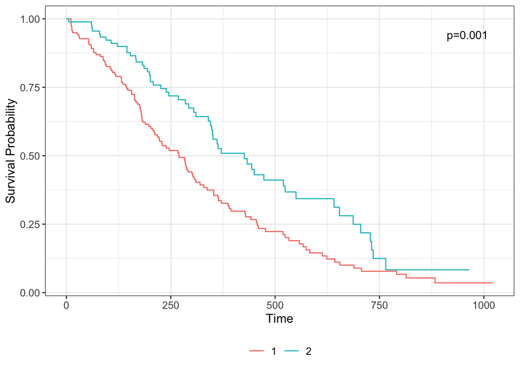

```r
library(survival)
library(ggsurvfit)

survfit2(Surv(time, status)~sex, data=lung) |>
ggsurvfit() + add_pvalue("annotation")
```

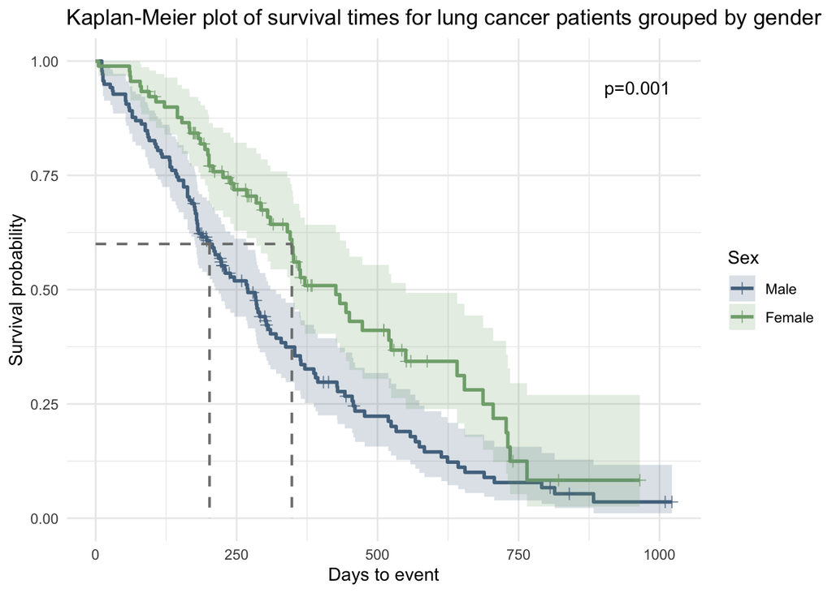

```r
survfit2(Surv(time, status)~sex, data=lung) |>
  ggsurvfit(linewidth = 1) + add_pvalue("annotation") +
  scale_color_manual(values = c('#54738E', '#82AC7C'), name = "Sex", labels = c("Male", "Female")) +
  scale_fill_manual(values = c('#54738E', '#82AC7C'), name = "Sex", labels = c("Male", "Female")) +
  theme_minimal() +
  add_confidence_interval() +
  add_censor_mark(size = 2, alpha = 0.8) +
  add_quantile(y_value = 0.6, color = "gray50", linewidth = 0.75) +
  labs(
    y = "Survival probability",
    x = "Days to event",
    title = "Kaplan-Meier plot of survival times for lung cancer patients grouped by gender"
  )
```

## The Log-rank test

`survdiff()` tests for differences in survival between two or more groups using a log-rank test. More information about using the log-rank test in R can be found at this [Data Science Tutorial](https://datasciencetut.com/how-to-perform-a-log-rank-test-in-r/).

```r
library(survival)
s16_merge <- read_rds("https://github.com/UEA-Cancer-Genetics-Lab/Using-R-with-biological-datasets-2025/raw/refs/heads/main/data/s16_merge.rds")
survdiff(Surv(progression_days, progression)~abbs, data=s16_merge)$pvalue
```

```
[1] 0.0451893
```

### Exercise - Log-rank test

#### Setup script

```r
library(survival)
library(ggsurvfit)
```

#### Tasks

1. Determine the log-rank test p-value for gender in the `lung` dataset

#### Answers

```r
survdiff(Surv(time, status)~sex, data=lung)$pvalue
```

```
[1] 0.001311165
```

## Cox regression

The need for the Cox Proportional Hazards Model due to Kaplan-Meier curves and log-rank tests are limited:

- Univariate only
- Categorical only

In most situations these limitations are not met.

Cox regression is a linear regression model that can be thought of as a form of logistic regression where the time at which the event occurs is also taken into account. The **hazard function** $h(t)$ for an individual at time $t$ is modeled as:
$$h(t) = h_0(t) \exp( \beta_1 x_1 + \beta_2 x_2 + \dots + \beta_p x_p )$$
Where:

- $h(t)$ is the **hazard function** at time $t$, representing the instantaneous rate of an event occurring at time $t$, given that the event has not occurred before time $t$.
- $h_0(t)$ is the **baseline hazard function**, which is the hazard when all predictors are equal to zero. It is not estimated explicitly but is stratified out of the model.
- $\exp(\dots)$ denotes the **exponential function**.
- $\beta_1, \beta_2, \dots, \beta_p$ are the **regression coefficients** for the predictors. These coefficients represent the effect of each predictor on the hazard. A positive $\beta$ indicates an increased hazard, and a negative $\beta$ indicates a decreased hazard.
- $x_1, x_2, \dots, x_p$ are the **predictor variables** (covariates) for an individual. These can be continuous, categorical, or binary.

The core assumption of the Cox model is the **proportional hazards assumption**, which states that the ratio of hazards between any two individuals is constant over time. This means that the effect of a covariate on the hazard is the same at any point in time.

$$HR(t) = h_1(t)/h_0(t) = e^{\beta_1}$$

- $HR(t) = 1$: No effect
- $HR(t) < 1$: Reduction in the hazard (a good prognostic factor i.e. protective)
- $HR(t) > 1$: Increase in hazard (a bad prognostic factor)

```r
mod_res <- coxph(Surv(progression_days, progression)~abbs, data=s16_merge) |>
  tidy(exponentiate=TRUE, conf.int=TRUE)
mod_res
```

```
# A tibble: 1 × 7
  term     estimate std.error statistic p.value conf.low conf.high
  <chr>       <dbl>     <dbl>     <dbl>   <dbl>    <dbl>     <dbl>
1 abbsTRUE     6.18      1.04      1.75  0.0797    0.806      47.3
```

Hazard ratio = 6.2 (95% Confidence Interval 0.8-47.3), *p* = 0.08.

### Exercise - Cox regression

#### Introduction

Using the `lung` dataset create some Cox regression models

#### Startup script

```r
library(survival)
```

#### Tasks

1. Create a univariate Cox model of sex. Compare with the log-rank test.
2. Let’s create another model where we analyse all the variables in the dataset.
3. (stretch) Repeat the above with the `colon` or `ovarian` datasets

#### Answers

```r
library(survival)
#1
fit <- coxph(Surv(time,status)~sex, data=lung) |>
    tidy(exponentiate=TRUE, conf.int=TRUE)
fit
```

```
# A tibble: 1 × 7
  term  estimate std.error statistic p.value conf.low conf.high
  <chr>    <dbl>     <dbl>     <dbl>   <dbl>    <dbl>     <dbl>
1 sex      0.588     0.167     -3.18 0.00149    0.424     0.816
```

```r
#2
fit <- coxph(Surv(time,status)~
               sex+age+ph.ecog+ph.karno+pat.karno+meal.cal+wt.loss, data=lung) |>
tidy(exponentiate=TRUE, conf.int=TRUE)

fit
```

```
# A tibble: 7 × 7
  term      estimate std.error statistic p.value conf.low conf.high
  <chr>        <dbl>     <dbl>     <dbl>   <dbl>    <dbl>     <dbl>
1 sex          0.576  0.201       -2.74  0.00609    0.389     0.855
2 age          1.01   0.0116       0.917 0.359      0.988     1.03
3 ph.ecog      2.08   0.223        3.29  0.00101    1.35      3.23
4 ph.karno     1.02   0.0112       2.00  0.0457     1.00      1.05
5 pat.karno    0.988  0.00805     -1.54  0.123      0.972     1.00
6 meal.cal     1.00   0.000259     0.128 0.898      1.000     1.00
7 wt.loss      0.986  0.00777     -1.84  0.0652     0.971     1.00
```

This shows us how all the variables, when considered together, act to influence survival. Some are very strong predictors (sex, ECOG score). Interestingly, the Karnofsky performance score as rated by the physician was marginally significant, while the same score as rated by the patient was not.

### (Advanced) Checking Cox model assumptions

In order for our interpretation of the harzard ratios to be valid, two key assumptions need to hold:

1. Since $\beta_k$ is fixed for all time points we assume that the hazards are “proportional” over the entire study period. This is almost never the case for actual data.
2. We assume that loss to follow-up is random. In other words, there is no selection bias as a result of censoring prior to the end of the study.

We can check the proportion hazards assumption by seeing if the beta estimates change with time.

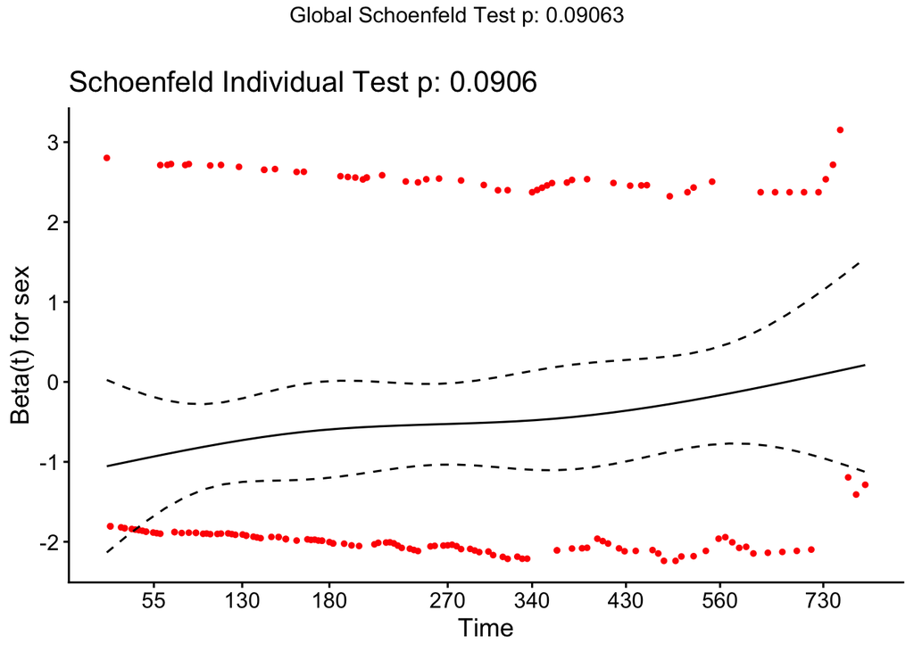

```r
library(survival)
library(survminer)
coxfit <- coxph(Surv(time,status)~sex, data=lung)
residuals <- cox.zph(coxfit)
ggcoxzph(residuals)
```

From the graphical inspection, there is no pattern with time. The assumption of proportional hazards appears to be supported for the covariate sex.

# Sources

- [R for Data Science (2e)](https://r4ds.hadley.nz/)
- [Biological Data Science with R](https://bdsr.stephenturner.us/)
- [Josef Fruehwald LSA 2017 Statistical Modelling with R](https://jofrhwld.github.io/teaching/courses/2017_lsa/)
- [Messy Datasets](https://github.com/higgi13425/medicaldata?tab=readme-ov-file#messy-datasets)
- [Sotware Carpentry - R for Reproducible Scientific Analysis](https://swcarpentry.github.io/r-novice-gapminder/13-dplyr.html)
- [JMP Statistics Knowledge Portal](https://www.jmp.com/en/statistics-knowledge-portal/)